# Uso e interpretación de datos

**Las Siete Herramientas de Control de Calidad (QC)** son técnicas importantes para resumir y analizar datos al abordar la resolución de problemas relacionados con la gestión de la calidad

En este capíturo, aprenderemos sobre Las Siete Herramientas de Control de Calidad (QC) y me gustaría que entiendan lo siguiente.

- Comprender el nombre y el contenido de cada una de Las Siete Herramientas de Control de Calidad (QC)
- Comprender las características, la forma de crearlas y las manera de interpretarlas para cada método.
- Comprensión de las situaciones en las que se utilizan Las Siete Herramientas de Control de Calidad (QC) para avanzar en la resolución de problemas.

[Audio_1](https://drive.google.com/file/d/1Mc-vqnrBNqHeYBZvHTA-geQn1NdVcNvt/view?usp=drive_link)

```python
import os

try:
  os.chdir('../Python/QCKentei4')
except:
  pass

path = os.getcwd()
path
```

```
'/Users/takanohiroshi/Library/CloudStorage/OneDrive-個人用/Documenten/Python/QCKentei4'
```

```python
import numpy as np
import matplotlib.pyplot as plt
import pandas as pd
import random
from scipy.stats import norm

from PIL import Image

import gspread
from google.oauth2.service_account import Credentials
```

## 08-01 Las Siete Herramientas de Control de Calidad (QC)

QC七つ道具

### 1. Las Siete Herramientas de Control de Calidad (QC)

QC七つ道具とは

En la **gestión de calidad**（品質管理）, es importante extraer información de los datos recopilados, reflexionar sobre esa información y tomar las medidas adecuadas. Por lo tanto, la información obtenida de los datos debe ser precisa y, debe ser a través de un método eficiente.

**Las Siete Herramientas de Control de Calidad (QC)** son instrumentos relacionados con la **forma de resumir datos**（データのまとめ方）, que permiten procesarlos y representarlos gráficamente, haciendo **visible la información**（データの見える化）. Se utilizan frecuentemente en la **resolución de problemas**（問題解決） dentro de la gestión de la calidad.

Las siete herramientas del control de calidad permiten representar los **datos en gráficos**（グラフ化） para extraer información de forma sencilla.

#### (1) Características de Las Siete Herramientas de Control de Calidad (QC):

QC七つ道具の特徴

1. **Metodologías sencillas** que cualquiera puede utilizar de inmediato. やさしい手法で誰でもすぐに使える
2. Se utilizan principalmente para analizar **datos numéricos**. 主に数値データを解析する
3. Se emplean en diversas etapas de la **resolución de problemas**. 問題解決のいろいろな場面で使用する
4. Las metodologías se representan gráficamente, lo que permite **comprender los resultados de un vistazo**. 手法は図で示され、一目で結果が理解できる

[Audio_2](https://drive.google.com/file/d/1ShVPQYHDI6Lr-Jj_SkpLhymbIguLAk02/view?usp=drive_link)

#### (2) Las Siete Herramientas de Control de Calidad (QC) y la Estratificación:

QC七つ道具の各手法

1. **Diagrama de Pareto**: パレート図 Permite identificar los **problemas prioritarios**（重点指向） en los que se debe enfocar la atención.
2. **Diagrama de Causa-Efecto** (Diagrama de Ishikawa o Diagrama de Espina de Pescado): 特性要因図 Organiza las **relaciones entre un efecto (característica) y sus posibles causas (factores)**（特性と要因の関係）.
3. **Hoja de Verificación** (Checklist o Hoja de Recolección de Datos): チェックシート Facilita la **recolección y el registro de datos de forma sencilla**（簡単に収集・記録）, así como la **realización de inspecciones y verificaciones**（点検・確認）.
4. **Histograma**: ヒストグラム Permite comprender la **tendencia central** y la **dispersión**（データの中心やばらつき） de los datos.
5. **Diagrama de Dispersión**: 散布図 Ayuda a identificar la **relación entre dos conjuntos de datos emparejados**（２つのデータ間）.
6. **Gráficos** (Diagramas): グラフ Permiten visualizar la **magnitude**（大小） de los datos y **su evolución en el tiempo**（時間的推移）.
7. **Gráfico de Control**: 管理図 Ayuda a comprender la variación de un proceso a lo largo del tiempo y a determinar si el **proceso se encuentra bajo control estadístico**（工程が管理状態）.
8. **Estratificación**: 層別 Divide los datos en **grupos**（グループ） en función de sus **similitudes** o **características comunes**（共通点や特徴）.
- Las siete herramientas del control de calidad (QC siete herramientas) generalmente se refieren a las herramientas (1) a (7). La estratificación (8) no está incluida en las siete porque es más un concepto que una técnica. Sin embargo, dado que la estratificación es un concepto importante, a veces se agrupan los gráficos y los diagramas de control como "**6. Gráficos y diagramas de control**" y se incluye "**7. Estratificación**", llamando a estas siete herramientas las "siete herramientas del QC".

[Audio_3](https://drive.google.com/file/d/11xxjumdAuESEYstoHh6IVisF-jXyh095/view?usp=drive_link)

### 2. Diagrama de Pareto

パレート図

En la vida diaria, cuando un grupo numeroso de personas tiene que tomar una decisión, a veces se decide por mayoría de votos. Estas es una forma de tomar decisiones considerando las opiniones de la mayoría. De manera similar, en la **resolución de problemas**, es necesario concentrarse en los elementos que tienen **mayor cantidad** o **impacto**.

Un **Diagrama de Pareto** es una **gráfica**（グラフ化） que organiza valores de una característica específica (como frecuencia de ocurrencia o pérdidas económicas) en categorías, ordenadas de mayor a menor cantidad de tados, permitiendo identificar de un vistazo en qué categorías se debe **enfocar la atención**.

Por ejemplo, cuando se les pregunta a los estudiantes de primaria qué quieren ser de mayores, muchos eligen profesiones populares, mientras que el resto, un grupo más pequeño, tiene una variedad de opciones sin una inclinación clara hacia ninguna en particular.

No solo en este ejemplo, sino que en general, una minoría de elementos son responsables de la mayor parte del impacto, mientras que la mayoría de los elementos tienen un impacto menor, a pesar de ser numerosos. Esto se conoce como el **Principio de Pareto** (o **Ley de Pareto**)（パレートの法則）.

El diagrama de Pareto, que se basa en la **ley de Pareto**, se utiliza a menudo para decidir qué problemas abordar de forma prioritaria cundo hay varios problemas. En otras palabras, es un método que permite visualizar que es lo más importante basándose en los datos.

El diagrama de Pareto es una de las herramientas de **enfoque prioritario**（重点指向）. Se utiliza para decidir, con un enfoque prioritario, a qué problemas se va a dar solución y para establecer los objetivos de mejora al abordar la resolución de un problema.

[Audio_4](https://drive.google.com/file/d/174Gv1WcKuT611t1y5alKCe37zQJ27DyM/view?usp=drive_link)

#### (1) Cómo elaborar un diagrama de Pareto

パレート図のつくり方

1. Se toman datos sobre el número de defectos, la cantidad de pérdidas o el número de fallos, y se clasifican por causa, fenómeno, proceso o tipo de producto. Luego, los datos **se ordenan de mayor a menor** y su magnitud se representa con la **altura de una barra**. En este caso, los elementos con un número de datos pequeño menor se agrupan en una categoría llamada otros y se colocan al final de la lista de elementos.
2. Luego, se muestra en un **gráfico de lineas** la suma acumulada de los datos, ordenados de mayor a menor. De esta manera, se puede ver qué proporción del total representan los elementos a los que se les debe dar prioridad.

[Audio_5](https://drive.google.com/file/d/16oZ05yO1QB3raCB8t2aKibkH4L7Chb-f/view?usp=drive_link)

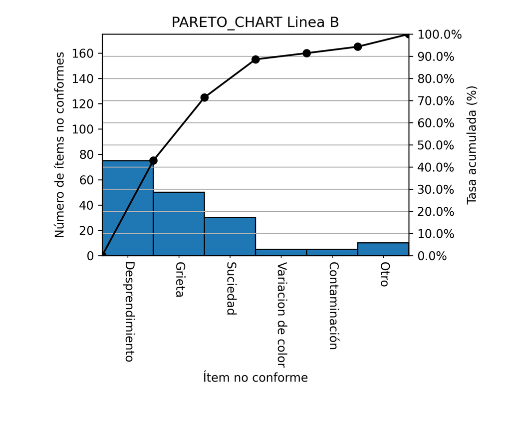

```python
from PIL import Image
img = Image.open('./Data4/Pareto_Chart.png')
display(img)
```

#### (2) Características del diagrama de Pareto

パレート図の特徴

1. Se puede ver el orden de importancia de los elementos o la magnitud de los problemas（重要な項目）.
2. Puede ver qué porcentaje del total representa cada elemento.
3. Se puede predecir el efecto que se obtendrá al reducir un determinado elemento.
4. Al comparar antes y después de implementar una medida, se puede ver cómo ha cambiado el efecto sobre el objetivo y el contenido de los elementos.

#### (3) Puntos clave para la aplicación del diagrama de Pareto

パレート図の活用ポイント

1. Puedes investigar qué tan efectivo sería reducir un elemento en particular y en qué medida.
2. Observa los problemas desde diferentes ángulos e intenta cambiar la forma de clasificarlos.
3. Si la cantidad de datos en la categoría "otros" es demasiado grande, se debe reconsiderar el método de clasificación de los valores característicos.
4. Para comparar los diagramas de Pareto de antes y después de una mejora, es útil mantener la escala del eje vertical igual, ya que así se puede entender mejor el efecto de la mejora.

[Audio_6](https://drive.google.com/file/d/1H36gBEq-UZIyK473j34A8Y_DBEzniqta/view?usp=drive_link)

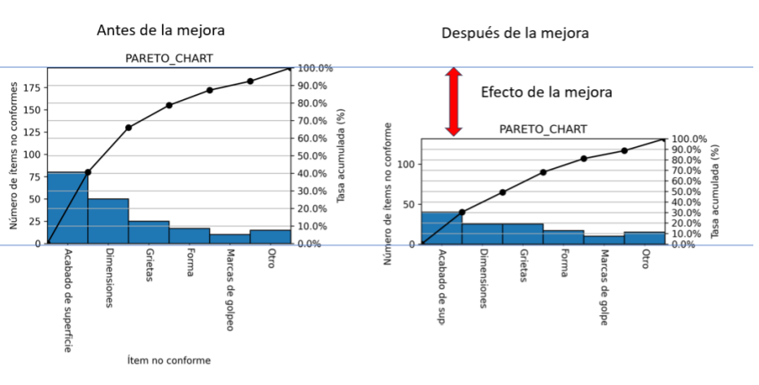

```python
img = Image.open("./Data4/Pareto3.png")
display(img)
```

### 3. Diagrama de Causa-Efecto (Diagrama de Ishikawa o Diagrama de Espina de Pescado)

特性要因図

En nuestra vida cotidiana, enfrentamos una variedad de problemas. Para resolverlos, debemos tomar medidas que aborden sus causas. Sin embargo, hay muchos factores que influyen en un problema, por lo que es necesario encontrar las causas que tienen un impacto más significativo.

Un **Diagrama de Causa-Efecto** es una representación gráfica que muestra sistemáticamente la relación entre un **resultado**結果 (**característica**特徴) y sus **causas**原因 (**factores**要因), siendo una técnica para organizar cómo los factores están relacionados con la característica.

En la resolución de problemas, al investigar las causas,se utiliza el diagrama de causa y efecto (o diagrama de Ishikawa) para organizar las relaciones de causa y efecto y para extraer los diversos factores que influyen en el problema.

#### (1) Cómo elaborar un diagrama de causa-efecto

特性要因図のつくり方

1. Elige la característica que será el problema y anota la característica y la espina dorsal del diagrama. Después, añade los huesos grandes, medianos, pequeños y sus sub-ramas. Al hacerlo, organiza los factores del tal manera que estén conectados de forma sistemática y, en lo posible, especifica los factores de manera concreta.
2. Verifica que no falte ni se omita ningún factor, y marca los que consideres importantes.

[Audio_8](https://drive.google.com/file/d/1RqR_JzLeu7IFLcEvuJs4UmyLqH-_tEyx/view?usp=drive_link)

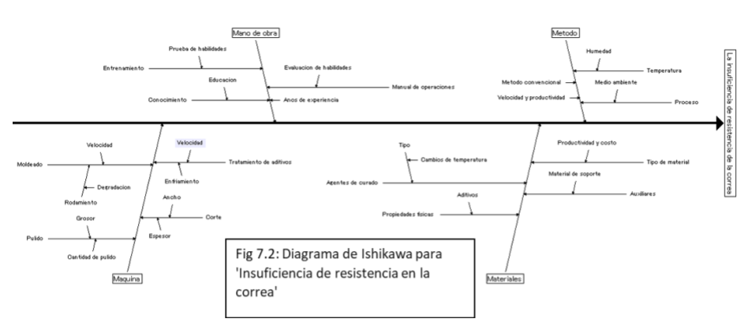

```python
img = Image.open("./Data4/DiagramaDeIshikawa.png")
display(img)
```

#### (2) Puntos a tener en cuenta al crear un diagrama de causa-efecto

特性要因図の作成時の注意点

1. Para recopilar la mayor cantidad de conocimientos e ideas, es crucial no crearlo solo, sino con la participación de muchos colaboradores. Utilizar sesiones de lluvia de ideas (brainstorming) es una forma efectiva de hacerlo.
2. La característica debe expresarse como una manifestación de un resultado negativo.
3. Para organizar los factores de manera sistemática, es fundamental expresarlos de la forma más concreta posible y aclarar las relaciones entre ellos. Una forma útil de extraer estos factores es agruparlos según las **4M**: Mano de obra (Man), Máquina (Machine), Material (Material), Método (Method)
4. Procura mencionar la mayor cantidad de factores posibles y no especifiques el nivel (la magnitud)

#### (3) Puntos clave para la aplicación del diagrama de causa-efecto

特性要因図の活用ポイント

1. El diagrama de causa y efecto se utiliza para analizar y mejorar los procesos, así como para llevar a cabo su control.
2. Toma medidas para abordar los factores importantes que influyen en la característica.

[Audio_9](https://drive.google.com/file/d/11Qsj630vMsI599My0vnSXlaUDFOHMlM2/view?usp=sharing)

### 4. Hoja de Verificación

チェックシート

Al contar objetos en la vida diaria o al recopilar datos de inspección en una fábrica, no se deben cometer errores como contar mal o pasar por alto una inspección. Por ello, es necesario idear métodos de recopilación de datos para garantizar la precisión y evitar errores.

Una **Hoja de Verificación** (o Checklist) es un diagrama o tabla donde se definen de antemano los elementos a verificar, facilitando la recolección sencilla de datos, su organización y el registro de manera que se pueda comprender fácilmente la situación general.

- Hoja de verificación para registro e investigación: El objetivo de una hoja de verificación para registro e investigación es recopilar datos con el fin de cumplir con los propósitos de la inspección. Principalmente, maneja datos sobre el contenido de defectos, la ubicación de las fallas y las distribuciones de frecuencia.
- Hoja de verificación para inspección y confirmación: El objetivo de una hoja de verificación para la inspección y confirmación es asegurar que se cumplan los puntos de control preestablecidos. Se utiliza principalmente para la inspección de maquinaria y equipo, mantenimiento diario, operaciones de seguridad y para mantener el orden y la limpieza.

En la resolución de problemas, la hoja de verificación se utiliza para la recopilación de datos al momento de entender la situación actual y para confirmar los resultados después de implementar una mejora.

#### (1) Características de la hoja de verificación

チェックシートの特徴

1. Como no lleva mucho tiempo registrar los datos, se puede tomar de forma eficiente en el lugar de trabajo.
2. Se puede actuar rápidamente porque se sabe en qué elementos se concentran los datos y se puede ver el panorama general.
3. Hace que la recopilación de datos sea más fácil, permitiendo recopilar o verificar muchos elementos al mismo tiempo.

#### (2) Puntos tener en cuenta al crear una hoja de verificación

チックシート作成時の注意点

1. ¿La hoja de verificación cumple con el propósito de la toma de datos?
2. ¿Se ha diseñado para recopilar los datos de una manera que sea fácil de organizar?
3. ¿La hoja de verificación también tiene campos para registrar, además de los datos, la fecha, el nombre del encargado, el método y el entorno de la medición?

[Audio_10](https://drive.google.com/file/d/1CguUSkrmDHdSvXn8hwoTnxivAE-OM_dF/view?usp=drive_link)

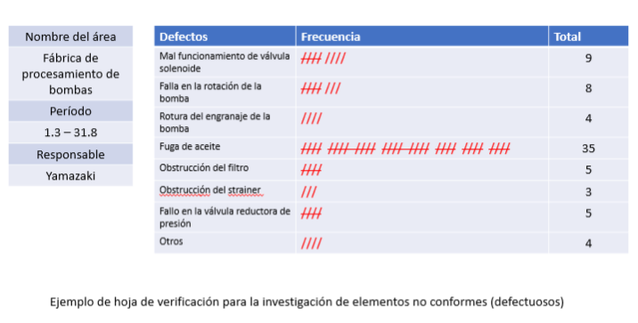

```python
img = Image.open("./Data4/Hoja de verificación.png")
display(img)
```

### 5. Histograma

ヒストグラム

En nuestro entorno hay una gran cantidad de datos numéricos. Sin embargo, el simple hecho de observar los números no nos da información detallada como la **posición central** o la **dispersión** (distribución) de los datos, lo que dificulta tomar medidas. Para obtener información a partir de los datos numéricos, es necesario procesarlos y representarlos **visualmente en gráficos** para que sean más fáciles de entender.

Un **histograma** es un diagrama de barras que representa la distribución de un conjunto de datos. Los datos se dividen en intervalos (clases) y la altura de cada barra indica la frecuencia (número de datos) que cae dentro de ese intervalo. Permite visualizar la distribución de los datos y su relación con las especificaciones.

Para la **resolución de problemas**, se utilizan histogramas para investigar las causas, ya que permiten **visualizar** la forma de la **distribución**, la **media** y la **dispersión**, entre otras cosas.

##### (1) Cómo elaborar un histograma

ヒストグラムのつくり方

1. Para datos de **valores medidos**, como la longitud, el peso, el tiempo o la dureza, se divide el rango en el que se encuentran los datos en varios intervalos, se cuenta la frecuencia de los datos que caen en cada intervalo y se crea una **tabla de frecuencias**.
2. Al alinear un **gráfico de barras** con la altura de la frecuencia de cada intervalo, se puede ver la distribución general de los datos.
3. Si se dispone de un **valor medio** o un **valor estándar**, se puede dibujar una línea para ver qué tan bien se ajustan los datos a la especificación.

##### (2) Cómo interpretar un histograma

ヒストグラムの見方

1. Se puede observar la tendencia central y el grado de dispersión desde las siguientes perspectivas.
   - ¿Cuál es la forma de distribución?
   - ¿Cuál es la posición central de la distribución?
   - ¿Cuál es la dispersión de los datos?
2. Juzgar si la calidad del producto cumple con las especificaciones.

[Audio_11](https://drive.google.com/file/d/1BK_klvRaKNtuk6sPU_aM4uz-MmmoeS0U/view?usp=drive_link)

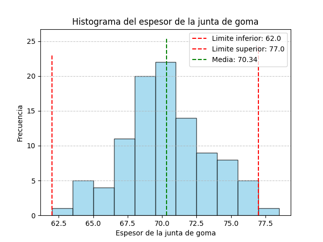

```python
img = Image.open("./Data4/Histograma.png")
display(img)
```

#### (3) Sobre la distribución del histograma

ヒストグラムの分布について

Diversas formas de histogramas.

[Audio_12](https://drive.google.com/file/d/1JqPGrMsjKnGFF7cBdt7nDPuDelo_mkvn/view?usp=drive_link)

#### Forma general (tipo normal)

一般形（正規分布型）

- Forma de la distribución normal

Los datos calculados obtenidos de un proceso estable tienden a mostrar una distribución en forma de campana (forma de distribución normal), con una parte central alta y colas que se extienden hacia los lados.

[Audio_13](https://drive.google.com/file/d/1SpuZYL4k1FnNwPWtr1jC5SZ20XfiA0Jf/view?usp=drive_link)

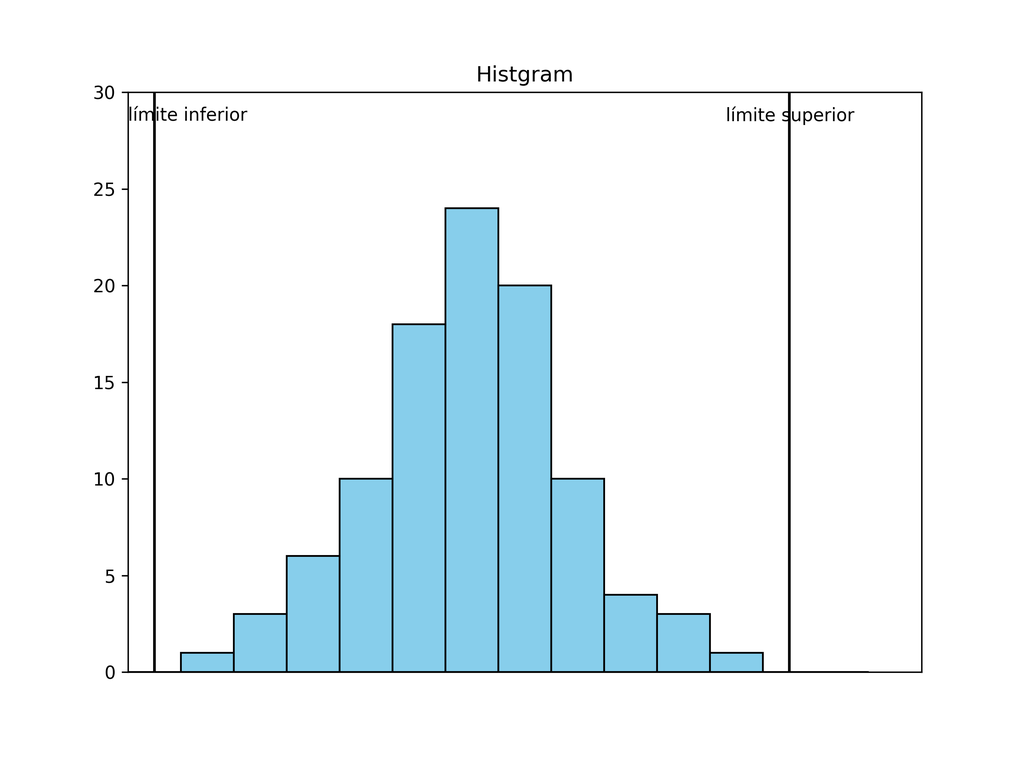

```python
img = Image.open("../QCKentei3/Graph3/Histgram1.png")
display(img)
```

### Tipo con juegos

歯抜け型

- Es común que haya problemas en la forma de organizar

A menudo, este tipo de forma se debe a problemas en la forma en que se agruparon los datos al crearlo. Si el ancho de los intervalos no se tomó como un múltiplo entero de la unidad de medida, o si los datos se leyeron de forma sesgada durante la medición, se obtendrá esta forma.

[Audio_14](https://drive.google.com/file/d/1l4uctqC6m96NzCywOZqviLSjFVI5aVfu/view?usp=drive_link)

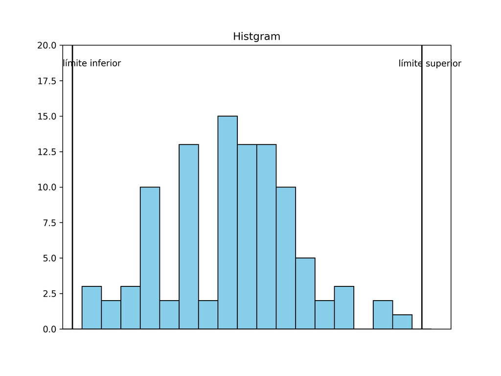

```python
img = Image.open("../QCKentei3/Graph3/Histgram2.png")
display(img)
```

### Forma de dos picos

二山型

- Existen dos distribuciones con medias diferentes.

Si la distribución presenta dos picos, esto indica que hay dos distribuciones con medias diferentes mezcladas. En este caso, es necesario identificar si existe algún factor de estratificación, dividir los datos en dos grupos y volver a crear los histogramas.

[Audio_15](https://drive.google.com/file/d/1MNyxUQOFDwBMuWVvNTVxF-X5uhyH6YFu/view?usp=drive_link)

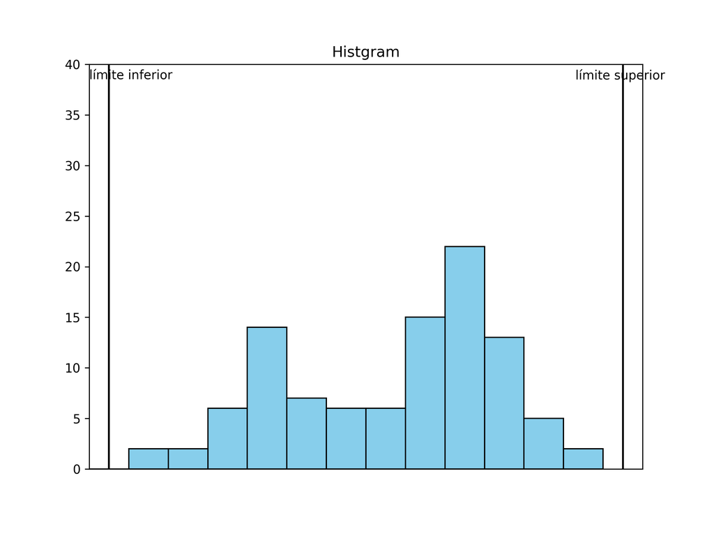

```python
img = Image.open("../QCKentei3/Graph3/Histgram3.png")
display(img)
```

### Forma de islas dispersas

離れ小島形

- Es común que la distribución tenga forma de islas dispersas debido a anomalías en el proceso, contaminación de muestras diferentes o errores en la medición.

Cuando hay anomalías en el proceso, mezcla de muestras diferentes o errores de medición, a menudo se observa una distribución con valores aislados. Es necesario investigar la causa y tomar medidas correctivas.

[Audio_16](https://drive.google.com/file/d/1Ko5UxhmijlJpb6-5IocsqoFdicU5NVBZ/view?usp=drive_link)

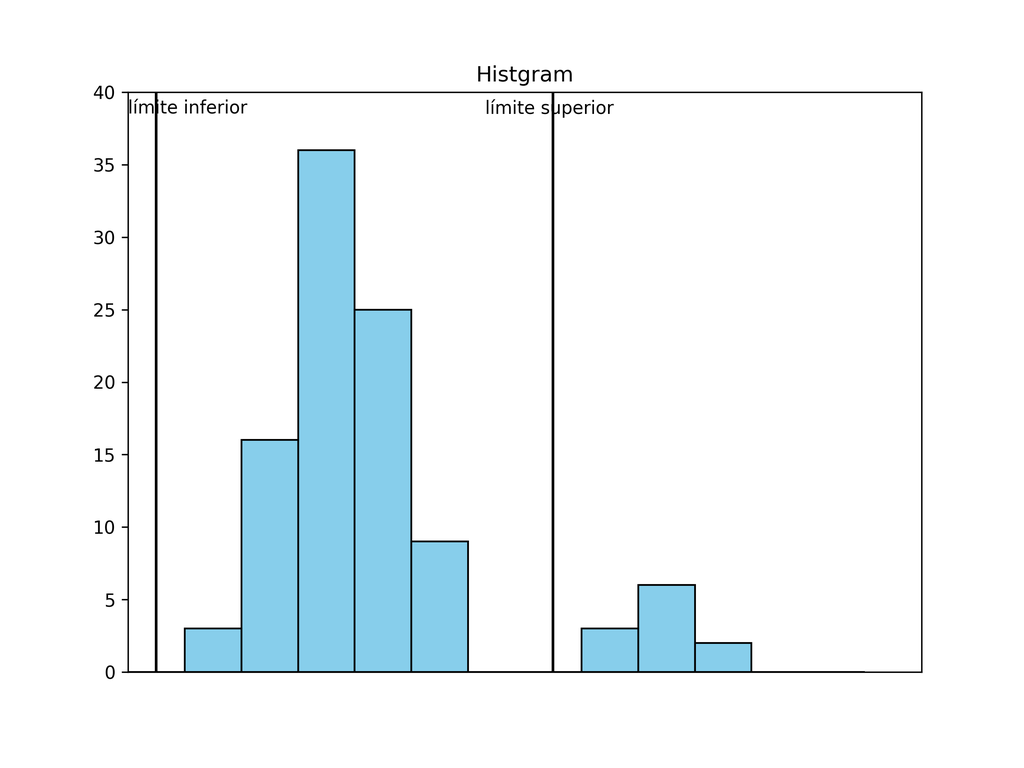

```python
img = Image.open("../QCKentei3/Graph3/Histgram4.png")
display(img)
```

### Forma de acantilado

絶壁形

- Se han eliminado los elementos fuera de especificación

En realidad, debieron existir datos fuera de límites abruptos. Esto ocurre cuando se realiza una inspección al 100% y se eliminan los elementos fuera de especificación, o cuando se manipulan los elementos que estarían fuera de especificación para que entren dentro de los límites.

[Audio_17](https://drive.google.com/file/d/1IyQ25uXcDhkN4JRNq3PYvgrMfotBfF67/view?usp=drive_link)

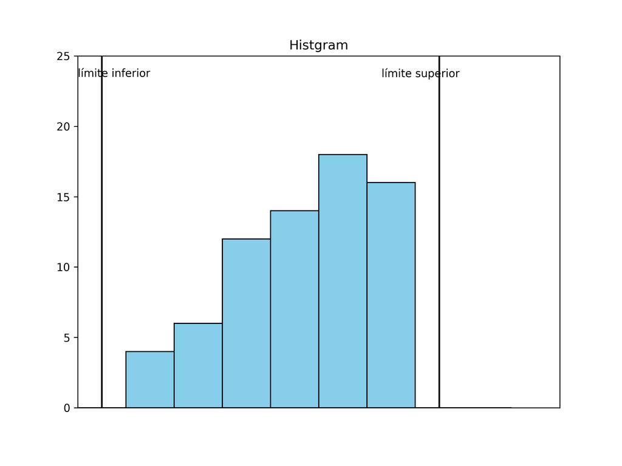

```python
img = Image.open("../QCKentei3/Graph3/Histgram5.png")
display(img)
```

### 6. Diagrama de Dispersión

散布図

En nuestras vidas hay una gran cantidad de datos numéricos y algunos de ellos tienen una **relación de causa y efecto**.

Un Diagrama de Dispersión es una gráfica que muestra la **relación mutua** (correlación) entre dos tipos de **datos emparejados**.

En la resolución de problemas, se utiliza un diagrama de dispersión para ver si existe una **correlación**（相関関係） y cuál es el **grado** de la misma entre dos conjuntos de datos emparejados de causa (factor x) y efecto (característica y).

Se dice que hay una **correlación** cuando existe algún tipo de relación entre $ x $ e $ y $. Un diagrama de dispersión es una técnica para investigar esta correlación.

En cuanto a la correlación, se dice que hay una **correlación positiva**（正の相関） cuando la relación es que, a medida que $ x $ aumenta, $ y $ también lo hace. Por el contrario, la relación en la que a medida que $ x $ aumenta, $ y $ disminuye, se llama **correlación negativa**（負の相関）.

#### (1) Cómo elaborar un diagrama de dispersión

散布図のつくり方

1. Se recolectan dos tipos de datos emparejados, como características y factores, o resultados y causas, y se grafican en los ejes vertica (eje y) y horizontal (eje x).
2. A partir de la dispersión de los puntos en un diagrama de dispersión, se puede determinar si existe una correlación entre los dos tipos de datos. También se identifica si hay puntos inusuales (valores atípicos) que se alejen del conjunto de datos.

[Audio_18](https://drive.google.com/file/d/1vmpjv2WfEj6MZCL1ecug4Xtco8odrIhp/view?usp=drive_link)

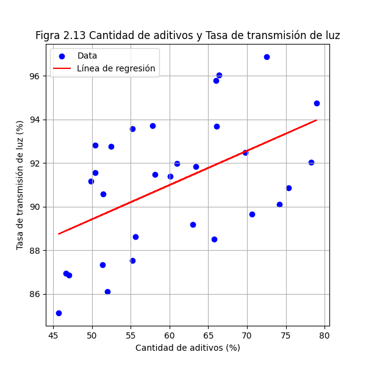

```python
img = Image.open("./Data4/Dispersión.png")
display(img)
```

#### (2) Cómo interpretar un diagrama de dispersión

散布図の見方

- Correlación positiva fuerte
  - A medida que $ x $ aumenta, $ y $ también aumenta.
  - Si se conoce el valor de $ x $, se puede estimar el valor de $ y $.
- Existe una correlación positiva débil:
  - Es posible que el valor de $ y $ esté siendo afectado por otros factores además de $ x $, por lo que es necesario investigar la relación con otras causas.
- Existe una correlación negativa fuerte:
  - A medida que $ x $ aumenta, $ y $ disminuye.
  - Si se conoce el valor de $ x $, se puede estimar el valor de $ y $.
- Hay una acellelación negativa débil:
  - Es posible que el valor de $ y $ esté siendo afectado por otros factores además de $ x $, por lo que es necesario investigar la relación con otras causas.
- No hay correlación:
  - Es necesario investigar otros factores además de $ x $ que puedan tener una correlación con $ y $.
- Relación no lineal:
  - La relación entre $ x $ e $ y $ no es lineal, pero se puede observar una relación cuadrática u otro tipo de relación entre ambas.

[Audio_19](https://drive.google.com/file/d/1QHb8ucf8qhZP6E-O2_-TPXDYaclWJb7N/view?usp=drive_link)

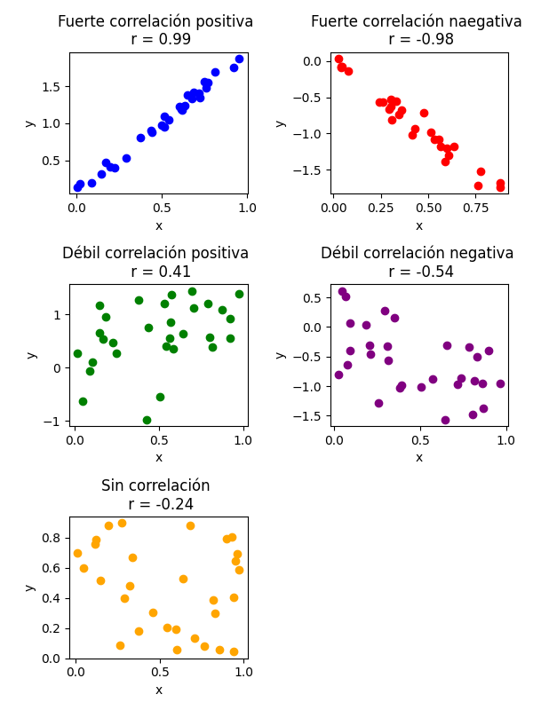

```python
img = Image.open("./Data4/Disperción10.png")
display(img)
```

#### (3) Puntos a tener en cuenta al observar un diagrama de dispersión

散布図を見るときの注意点

1. ¿Hay puntos anormales? / ¿Existen puntos atípicos? / ¿Se observan valores inusuales? 異常な点はないか
   - Al recolectar datos, a veces aparecen puntos que se alejan del grupo. En esos casos, se deben analizar los datos **exluyendo** esos puntos. Sin embargo, es importante investigar por qué los datos se alejan, ya que a menudo se puede obtener información útil al descubrir la causa. Por lo tanto, no solo se deben eliminar los datos alejados, sino que es crucial **indagar en la causa**.
2. ¿Cuál es la relación entre los dos conjuntos de datos? ¿Cómo es la relación entre los dos datos? / ¿Qué tipo de relación existe entre los dos datos? ２つのデータ間の関係はどうか
   - Se observa si existe una correlación, si la relación es lineal o si es curvilínea.
3. ¿Es necesario **estratificar** los datos? データを層別する必要がないか
   - Si bien al ver el conjunto de datos no parece ser necesario estratificar, en ocasiones, si se estratifica por proceso o por equipo, puede aparecer una correlación. También puede ocurrir lo contrario: al ver el conjunto de datos, parece que hay una correlación, pero al estratificar por proceso o por equipo, resulta que no la hay.
4. ¿No será una correlación espuria? / ¿No se tratará de una correlación falsa? / ¿Podría ser una correlación engañosa? 偽装間ではないか
   - Puede haber casos en los que exista una correlación entre dos conjuntos de datos correspondientes, pero no una relación de causa y efecto. En estos casos, uno de los datos aumenta, no afecta al otro.
5. ¿Cuál es la relación técnica? / ¿Cómo es la relación técnica? / ¿Existe una relación técnica? 技術的な関係はどうか
   - En un diagrama de dispersión, se puede determinar la existencia o no de una correlación, pero no se puede saber la razón de dicha correlación. Es necesario examinar técnicamente la relación entre los datos y verificar si dicha relación se sostiene.

[Audio_20](https://drive.google.com/file/d/1pvPsw657--b6c9YTEonf5Fxz3RljotpF/view?usp=sharing)

### 7. Gráficos (Diagramas)

グラフ

Diariamente, vemos a menudo gráficos de datos en la televisión, revistas e internet. Esto se debe a que, si se presentan los datos en una tabla tal cual, son difíciles de entender, por lo que se visualizan. En otras palabras, la visualización permite que la información se comprenda de forma fácil y rápida.

Un **Gráfico** (o Diagrama) es una representación visual de datos que permite comprender de un vistazo la magnitud de los valores y sus cambios a lo largo del tiempo, siendo la metodología más utilizada dentro de las site herramientas de la calidad.

En la resolución de problemas, se utilizan gráficos en diversas situaciones, como para comprender la situación actual, investigar las causas o verificar la efectividad de las contramedidas.

#### (1) Ventajas de los gráficos

グラフの利点

1. Permite captar de un vistazo la imagen completa de los datos.
2. Se pueden comparar los datos.
3. Se puede crear fácilmente.

#### (2) Tipos de gráficos y sus usos

グラフの種類と用途

1. Gráfico de líneas / Diagrama de líneas 折れ線グラフ
2. Gráfico de barras / Diagrama de barras 棒グラフ
3. Gráfico de circular / Diagrama de pastel / Gráfico de torta 円グラフ
4. Gráfico de barras apiladas / Diagrama de barras apiladas / Gráfico de banda 帯グラフ
5. Gráfico de radar / Diagrama de radar / Gráfico de araña / Diagrama de araña レーダーチャート

[Audio_21](https://drive.google.com/file/d/1niGpLD-yJBs-RwgNLoGXRXfq10D7l13g/view?usp=sharing)

**Gráfico de líneas**: 折れ線グラフ Un gráfico de líneas toma los valores de una característica en el eje vertical y marca los días o las horas en que se recopilaron los datos en el eje horizontal, uniéndolos con una línea.

Se utiliza principalmente para comprender la evolución de los datos a lo largo del tiempo. En un gráfico de líneas, si se cambian los tipos de líneas o puntos según los factores de estratificación, se pueden observar las diferencias en la tendencias temporales de cada uno de ellos.

[Audio_22](https://drive.google.com/file/d/1etz1BlqaXXstZ1cpLlLQCxeo4Wf-RTIE/view?usp=drive_link)

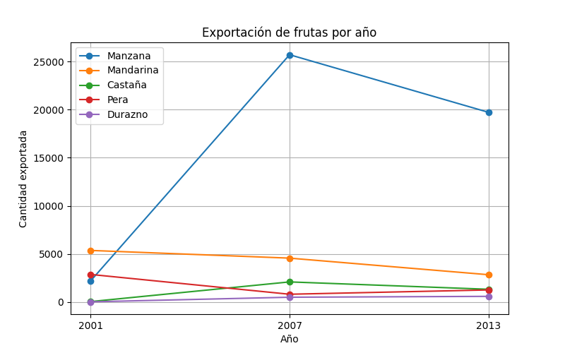

```python
img = Image.open("./Data4/GraficoDeLinea.png")
display(img)
```

**Gráfco de barras**: 棒グラフ Un gráfico de barras representa los valores de una característica en el eje vertical y las categorías de clasificación en el eje horizontal, mostrándose en forma de columnas.

El objetivo principal es mostrar la relación de magnitud entre las cantidades.

[Audio_23](https://drive.google.com/file/d/1oij67w-lrU-qiGfnMW6l1ff3uNCmJZz8/view?usp=drive_link)

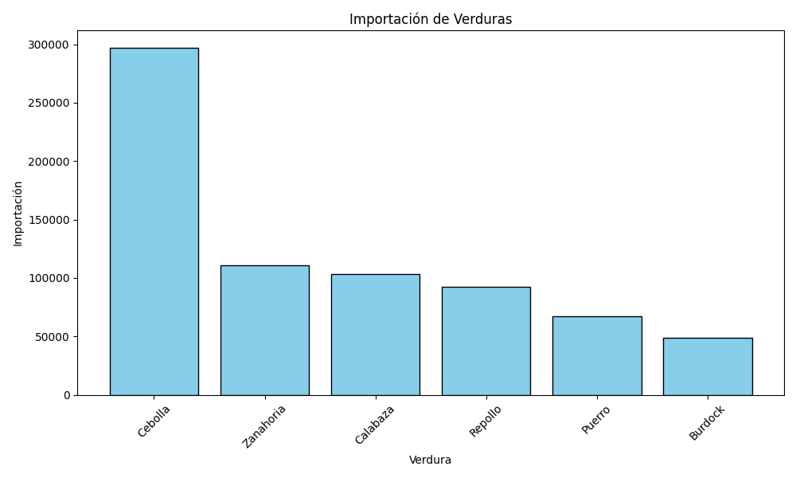

```python
img = Image.open("./Data4/GraficoDeBarras.png")
display(img)
```

**Gráfico circular** (o de pastel): 円グラフ Es un gráfico que representa el total como un círculo, y las proporciones de cada componente se muestran dividiendo el círclo en secciones.

Es fácil de entender, ya que la proporción de cada componente se representa por el tamaño del sector circular. Además, al cambiar el tamaño del círculo. se pueden mostrar simultáneamente las diferencias en la proporción y las diferencias en la magnitud de las cantidades.

[Audio_24](https://drive.google.com/file/d/1pTWB08rT0SV2Yv4F9FNrGjehUYv_7xfU/view?usp=drive_link)

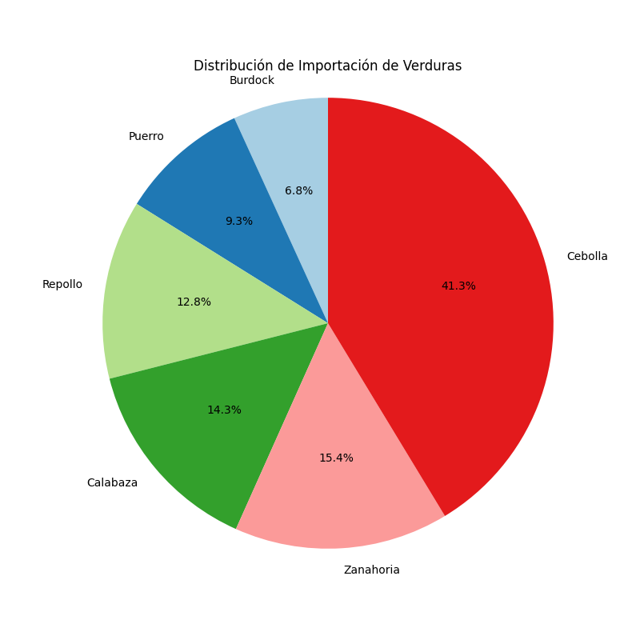

```python
img = Image.open("./Data4/GraficoCircular.png")
display(img)
```

**Gráfico de barras (o de cintas)**: 帯ブラフ Es un gráfico que representa el total como un rectángulo, y las proporciones de cada componente se muestran dividiéndolo en rectángulos más pequeños.

Al cambiar el tamaño del rectángulo total, se pueden comparar simultáneamente las diferencias en la proporción y en la magnitud de las cantidades. Por lo tanto, aunque su uso es muy similar al del gráfico circular, el gráfico de barras apiladas permite comparar más fácilmente las proporciones y las cantidades de un mismo componente al unirlos con una línea.

[Audio_25](https://drive.google.com/file/d/14ru0IhncZsXe99uWeCTQ656Cu_ZkizTT/view?usp=drive_link)

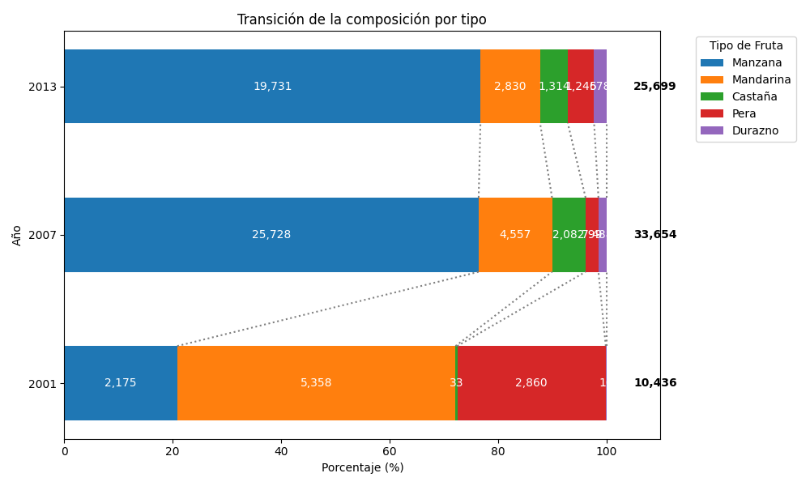

```python
img = Image.open("./Data4/GraficoDeBarraApiladas.png")
display(img)
```

El **gráfico de radar**: レーダーチャート Es un tipo de gráfico que se utiliza para visualizar el equilibrio entre varios elementos. Consiste en colocar escalas en la dirección de un polígono, marcar los datos de cada elemento y unirlos con líneas.

Se utiliza cuando se desea ver el grado de equilibrio de todos los elementos. Cuando hay varios gráficos de radar, se puede comparar la evaluación general comparando el tamaño de los polígonos.

[Audio_26](https://drive.google.com/file/d/1DB9dWXNBzRwyG0KA71Z1UV_Et-uDbF1y/view?usp=drive_link)

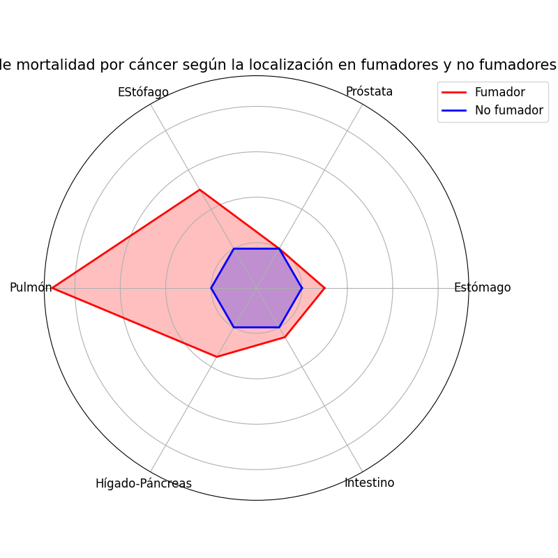

```python
img = Image.open("./Data4/GraficoDeRadar2.png")
display(img)
```

#### (3) Puntos a tener en cuenta sobre los gráficos

グラフの注意点

Hay varios tipos de gráficos, por lo que al organizar los datos y representarlos en un gráfico, la información se vuelve más fácil de interpretar que si solo se presentará en una tabla. Por lo tanto, es importante pensar en el propósito (qué se quiere comunicar y qué se quiere resaltar) y seleccionar el gráfico adecuado para ese objetivo.

[Audio_27](https://drive.google.com/file/d/1zPc8b1ZB6Os1tBA7aU2UG229Cg4ufbk-/view?usp=drive_link)

### 8. Gráfico de Control

管理図

Aunque un gráfico de líneas representa los datos trazando su movimiento a lo largo del tiempo, es necesario determinar si ese movimiento es estadísticamente significativo.

Un **Gráfico de Control** es una herramienta que utiliza un eje vertical para representar los valores de un estadístico (como la media, el rango, la tasa de defectos o el número de defectos) y un eje horizontal para representar las observaciones continuas (generalmente en función del tiempo o el número de muestra). Se utiliza para investigar si un proceso se encuentra en un estado de control estadístico (análisis de procesos) o para mantener un proceso en un estado controlado (control de procesos).

Los gráficos de control se utilizan para **detectar anomalías** en un proceso y para evaluar el estado de las **variaciones** y **tendencias** a lo largo del tiempo.

Cuando se gestiona un proceso, es necesario asegurarse de que no haya ocurrido ninguna anomalía y de que el proceso esté estable. Aunque no haya anomalías en el proceso, la calidad de cada producto varia, por lo que los datos también fluctúan. Por lo tanto, para detectar una anomalía en un proceso, es necesario distinguir si la dispersión de los datos se debe únicamente a **causas aleatorias** o a una **causa anormal**. Los gráfico de control son útiles para esto.

En los gráficos de control, para realizar juicios estadísticos, se dibujan tres líneas de control que se obtienen calculando a partir de los datos: la **línea central** (CL), el **límite de control superior** (UCL) y el **límite de control inferior** (LCL).

#### (1) Cómo elaborar un gráfico de control $ \bar{X} - R $

管理図のつくり方

1. Se crean subgrupos, se recopilan los datos, se calcula la media $ \bar{X} $ y el rango $ R $ para cada subgrupo, y se crea un gráfico de líneas para cada uno de ellos en orden cronológico. El tamaño del subgrupo debe ser de 2 a 5.
2. Para cada uno de los gráficos de control $ \bar{X} $ y $ R $, se calculan y se trazan la Línea Central (CL), el Límite de Control Inferior (LCL) y el Límite de Control Superior (UCL).
3. Verificar si hay alineaciones anómalas.

#### (2) Cómo interpretar un gráfico de control

管理図の見方

A continuación, se observa el gráfico de control desde las siguientes perspectivas para determinar si el proceso está bajo control o no. En ese momento, el proceso se considera **fuera de control** si se cumple alguna de las siguientes dos condiciones:

- El punto en el gráfico de control está fuera de los límites de control (LCL, UCL).
- Aunque los puntos están dentro de los límites de control, la forma en que se alinean y dispersan tiene un patrón peculiar.
  - Los puntos están en el mismo lado de la línea central (CL) de manera consecutiva.
  - Los puntos aumentan o disminuyen de forma consecutiva.
  - Los puntos varían periódicamente o regularmente.

  [Audio_28](https://drive.google.com/file/d/1G9RvJMMGe7wuIx-_sYkkdXxx4kjT9OJ7/view?usp=drive_link)

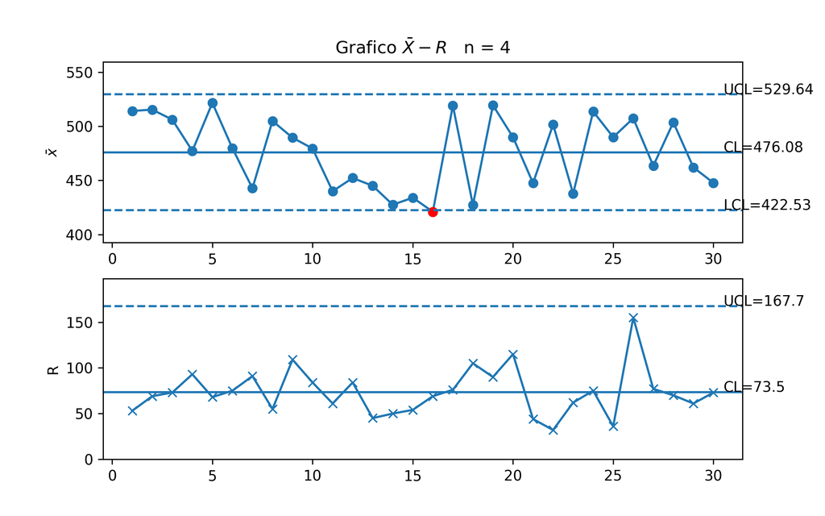

```python
img = Image.open("./Data4/Kanrizu.png")
display(img)
```

### 9. Estratificación

層別

Al crear un diagrama de Pareto, un diagrama de dispersión o un gráfico de control, si se comparan los datos dividiéndolo en grupos, se pueden identificar las diferencia entre estos.

La **estratificación** consiste en dividir los datos en varios **grupos (estratos)** en función de los **puntos en común**（共通点） o las **características que poseen**（特徴）.

En la resolución de problemas, al investigar las causas, se comparan las diferencias entre estratos para analizar la causa de la variación de los datos.

[Audio_29](https://drive.google.com/file/d/103zOIA_d46W-RhvbvcjMkRkaQgzHXLw9/view?usp=drive_link)

Este es un histograma creado para las dimensiones. Se puede observar que la distribución tiene dos picos. Por lo tanto, se realizó una estratificación por la Máquina 1 y la Máquina 2 y se crearon histogramas separados. No hay una diferencia significativa en la dispersión de ambas, pero se puede ver que la Máquina 1 tiene un promedio más bajo que la Máquina 2.

[Audio_30](https://drive.google.com/file/d/1ACS0lD6inqrgt0phIPOQwIhcb6_QVC2x/view?usp=drive_link)

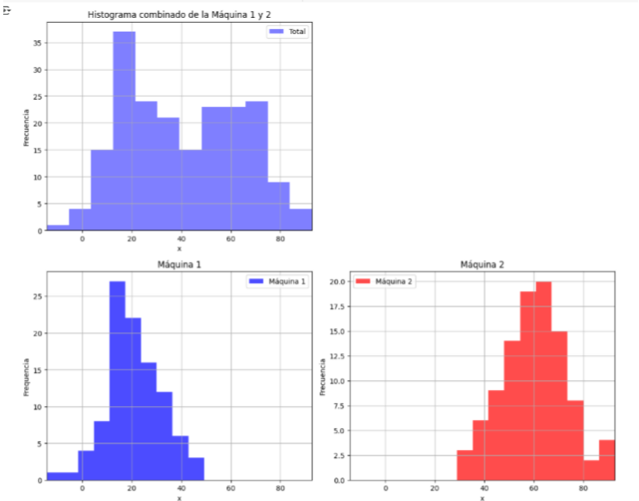

```python
img = Image.open("./Data4/8_19.png")
display(img)
```

Es una representación de la relación entre el número de visitantes y las ventas de un día en un centro comercial.

En general parece que **no hay correlación**, pero al estratificar y graficar los productos de bajo precio y uso general (Producto A: circulo azul) y los productos de alto precio y preferencia (Product B: círculo rojo), se observa que el Producto A tiene una **correlación positiva** entre el número de visitantes y las ventas. Por otro lado, el Producto B parece **no tener una relación de correlación**.

[Audio_31](https://drive.google.com/file/d/1mkF9VJWNL20t64mVQEBGvAI-KU02BLiz/view?usp=drive_link)

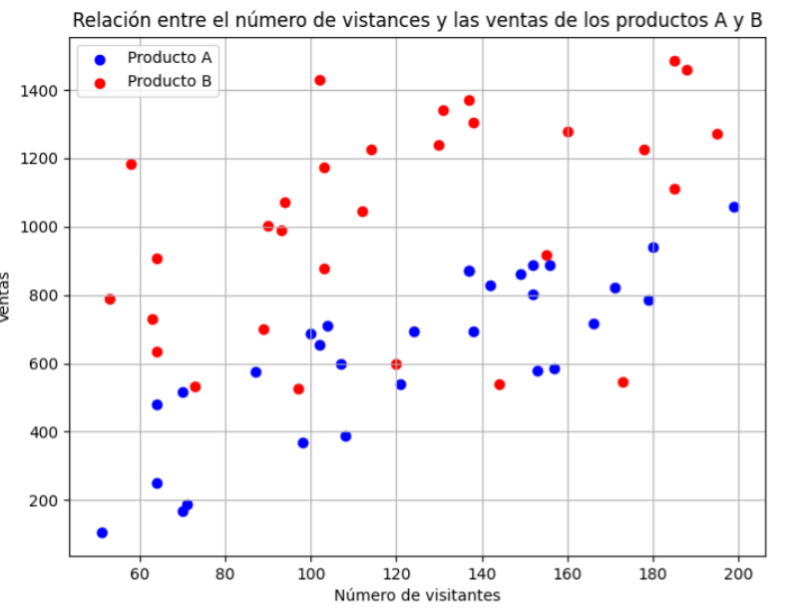

```python
img = Image.open("./Data4/8_20.png")
display(img)
```

#### (1) Puntos a tener en cuenta en la estratificación

層別の注意点

1. Para facilitar la estratificación, mantén claro el historial de los datos.
2. Intenta estratificar los datos con diferentes criterios.
3. Intenta estratificar los datos no solo por un factor, sino también combinando dos o más (por ejemplo, por material y por equipo).

[Audio_32](https://drive.google.com/file/d/1nhlSh1ktJCuErwAUM0B3VPyXUmn9y2EE/view?usp=drive_link)

## 08-02 Valor anormal

valor atípico/ Dato anómalo

### 1. ¿Qué es un valor anormal (valor atípico)?

¿Qué es un valor atípico (outlier)? / Definición de valor anormal (outlier)

Un valor atípico (o outlier) es un dato que aparece al recopilar información. Se refiere a un dato que se encuentra extremadamente alejado de los demás valores.

### 2. Respuesta a los valores anormales

Tratamiento de los valores atípicos / Cómo abordar los datos anómalos

[Audio_33](https://drive.google.com/file/d/1-y629c4xozYkbF3IgseO2zJ5wQsXB6L9/view?usp=drive_link)

## 08-03 Lluvia de Ideas (Brainstorming)

ブレーンストーミング

Es un método en el que varias personas comparten libremente sus opiniones e ideas para generar ideas y conceptos sobresalientes.

Las Cuatro Reglas: ４つのルール

1. Prohibido criticar (No criticar / Se prohíben las críticas) 批判禁止
2. Libre asociación (Ideas libres / Pensamiento libre). 自由奔放
3. Cantidad es importante (Generar mucha ides / La cantidad es clave). 量を多く
4. Aprovechar las ideas de otros (Construir sobre las ideas de otros / Se valora la combinación de ideas). 便乗歓迎

[Audio_34](https://drive.google.com/file/d/1Lcz-GMmueENdlKEhvLWWPqj-cJ3lx_uA/view?usp=drive_link)

### Simulacro de examen de QC Kentei

[Simulacro de examen de QC Kentei](https://forms.gle/TyAyD83jWxy9yViN8)

```python
notebook_name = 'QCKentei4-8.ipynb'
notebook_name_html = notebook_name.replace(".ipynb",".html")

!jupyter nbconvert --to html {notebook_name}
```

```
[NbConvertApp] Converting notebook QCKentei4-8.ipynb to html
[NbConvertApp] Writing 4180469 bytes to QCKentei4-8.html
```